# Markdown - Measuring the effects of AI introduction on MNEs’ innovative performance

# 1. Measuring technological distances: from 4-digit IPC codes to AI technologies, and from NACE sectors to AI.

In this first part, we measure the technology distance of different 4-digit IPC codes to the patents we defined as AI patents, and then we treat AI as a sector and measure the technological distance of NACE sectors to it.

## 1.1. Technological distance of 4-digit IPC codes to AI

We start by reading all patents that were linked to one of our MNEs or to their subsidiaries. These patents were already processed for allowing matching them directly to the MNE level (hence, patents from subsidiaries are allocated to their highest MNE level). Then, we read original Orbis files of the MNEs, and match them to the patents, so we can know which NACE sectors are linked to each patent. These are the only files with IP information from Orbis, so they can’t be shared. All of the remaining files used in the code are available online.

The patent file looks like this:

```r
head(all_patents)
```

| Company | Subsidiaries | PubNo | Priority_year | AIpatent | Subclass |
| --- | --- | --- | --- | --- | --- |
| AD*110181577359 | ESB85201465 | ES2377793B1 | 2009 | NA | H01L |
| AE*110000798230 | FR428745020 | FR2916012B1 | 2007 | NA | E21B |
| AE*110000798230 | FR428745020 | FR2916013B1 | 2007 | NA | E21B |
| AE*110000798230 | FR428745020 | FR2926566B1 | 2008 | NA | E02B |
| AE*110000798230 | FR428745020 | FR2936217B1 | 2008 | NA | B63B |
| AE*110000798230 | FR428745020 | KR1020100087094A | 2007 | NA | E02B |

The company files (there are six in total, there are ultimately merged into one) look like this:

```r
head(CompaniesData1)
```

| ...1 | Company name Latin alphabet | BvD ID number | BvD9 number | Country ISO code | NACE Rev. 2, core code (4 digits) | NACE Rev. 2, primary code(s) | Number of employees 2019...8 | Number of employees 2019...9 | Number of employees 2018 | Number of employees 2017 | Number of employees 2016 | Number of employees 2015 | Number of employees 2014 | Number of employees 2013 | Number of employees 2012 | Number of employees 2011 | R&D expenses / Operating revenue (%) 2019 | R&D expenses / Operating revenue (%) 2018 | R&D expenses / Operating revenue (%) 2017 | R&D expenses / Operating revenue (%) 2016 | R&D expenses / Operating revenue (%) 2015 | R&D expenses / Operating revenue (%) 2014 | R&D expenses / Operating revenue (%) 2013 | R&D expenses / Operating revenue (%) 2012 | R&D expenses / Operating revenue (%) 2011 | Operating revenue (Turnover) th USD 2019 | Operating revenue (Turnover) th USD 2018 | Operating revenue (Turnover) th USD 2017 | Operating revenue (Turnover) th USD 2016 | … |
| --- | --- | --- | --- | --- | --- | --- | --- | --- | --- | --- | --- | --- | --- | --- | --- | --- | --- | --- | --- | --- | --- | --- | --- | --- | --- | --- | --- | --- | --- | --- |
| 1. | WALMART INC. | US710415188 | 049986723 | US | 4719 | 4719 | 2200000 | 2200000 | 2200000 | 2300000 | 2300000 | 2300000 | 2200000 | 2200000 | 2200000 | 2200000 | NA | NA | NA | NA | NA | NA | NA | NA | NA | 523964000 | 514405000 | 500343000 | 485873000 | … |
| 2. | CHINA PETROLEUM & CHEMICAL CORPORATION | CN30086PC | 160144266 | CN | 0910 | 0910 | 402206 | 402206 | 423543 | 446225 | 451611 | 351019 | 358571 | 368953 | 376201 | 377235 | 0.316 | 0.274 | 0.271 | 0.304 | 0.279 | 0.199 | 0.220 | 0.209 | 0.194 | 425519389 | 422985274 | 363816410 | 281429407 | … |
| 3. | SINOPEC GROUP CO., LTD. | CN9360646475 | 287269073 | CN | 1920 | 1920 | 120 | 120 | NA | 120 | 120 | NA | NA | NA | NA | NA | NA | NA | NA | NA | NA | NA | NA | NA | NA | 394481648 | 391864625 | 331821836 | 249106775 | … |
| 4. | AMAZON.COM, INC. | US911646860 | 001812590 | US | 4761 | 4761 | 798000 | 798000 | 647500 | 566000 | 341400 | 230800 | 154100 | 117300 | 88400 | 56200 | 12.809 | 12.382 | 12.717 | 11.828 | 11.719 | 10.423 | 8.818 | 7.471 | 6.051 | 280522000 | 232887000 | 177866000 | 135987000 | … |
| 5. | CHINA NATIONAL PETROLEUM CORPORATION | CN9360812942 | 058878077 | CN | 1920 | 1920 | 703602 | 703602 | NA | NA | NA | NA | NA | NA | NA | NA | NA | NA | NA | NA | NA | NA | NA | NA | NA | 362264058 | NA | 327115447 | 240965507 | … |
| 6. | PETROCHINA COMPANY LIMITED | CN30081PC | 175129260 | CN | 0610 | 0610 | 460724 | 460724 | 476223 | 494297 | 508757 | 521566 | 534652 | 544083 | 548355 | 552810 | 0.622 | 0.592 | 0.611 | 0.685 | 0.677 | 0.572 | 0.620 | 0.658 | 0.66 | 360234861 | 316138635 | 309584425 | 235756868 | … |

Let’s keep only the information we need:

```r
CompaniesData <- CompaniesData[,c(2,3,6)]
names(CompaniesData) <- c("Company_name", "Company", "Nace_4d")
head(CompaniesData)
```

| Company_name | Company | Nace_4d |
| --- | --- | --- |
| WALMART INC. | US710415188 | 4719 |
| CHINA PETROLEUM & CHEMICAL CORPORATION | CN30086PC | 0910 |
| SINOPEC GROUP CO., LTD. | CN9360646475 | 1920 |
| AMAZON.COM, INC. | US911646860 | 4761 |
| CHINA NATIONAL PETROLEUM CORPORATION | CN9360812942 | 1920 |
| PETROCHINA COMPANY LIMITED | CN30081PC | 0610 |

Next, we introduce AI as a technology by copying AI patents into a new dataset, and changing their 4-digit IPC codes to a code named **“Artificial_Intelligence”**. Then, we merge it back to the dataset and calculate a co-occurrance matrix of all codes.

The co-occurrance matrix looks like this:

```r
print(as.matrix(mat_tech[1:20, 1:12]))
```

```
##      A01B A01C  A01D A01F  A01G  A01H A01J  A01K A01L A01M  A01N  A01P
## A01B 6526 1161   645   50   252     8    0     5    0  149    11     2
## A01C 1161 6710    71   16   580    82    0     8    0  386   372   270
## A01D  645   71 10082 1115   236    21    0    10    0   40    11     0
## A01F   50   16  1115 3362     8     0    0    24    0    3    10     7
## A01G  252  580   236    8 12912   387    1   290    0  316   450   341
## A01H    8   82    21    0   387 10704    0    73    0    7   384   229
## A01J    0    0     0    0     1     0  726    78    4    0     1     1
## A01K    5    8    10   24   290    73   78 11067    8   95   141    91
## A01L    0    0     0    0     0     0    4     8   26    0     1     0
## A01M  149  386    40    3   316     7    0    95    0 7486   721   626
## A01N   11  372    11   10   450   384    1   141    1  721 24615 11667
## A01P    2  270     0    7   341   229    1    91    0  626 11667 11825
## A21B    0    0     0    0     0     0    2     0    0    0     0     0
## A21C    0    1     0    0     0     0   12     0    0    0     0     0
## A21D    0    0     0    0     0    27    6    32    0    0    21    16
## A22B    0    0     0    0     0     0    0    10    0    3     1     0
## A22C    0    0     0    0     0     0    1    13    0    0     4     3
## A23B    0    5     1   45    19     2    3     9    0   11   138    57
## A23C    0    0     0    0     1     2   92    22    0    0    44    18
## A23D    0    1     1    0     5   199    8     0    0    0    20    10
```

Let’s now calculate the relatedness of every technology to AI:

```r
print(as.matrix(mat_tech[1:20, 1:5]))
```

```
##              A01B         A01C         A01D         A01F         A01G
## A01B 0.0000000000 0.1886886914 0.0971824664 0.0136373448 0.0285016871
## A01C 0.1886886914 0.0000000000 0.0115356250 0.0047058099 0.0707379713
## A01D 0.0971824664 0.0115356250 0.0000000000 0.3040211606 0.0266840140
## A01F 0.0136373448 0.0047058099 0.3040211606 0.0000000000 0.0016374225
## A01G 0.0285016871 0.0707379713 0.0266840140 0.0016374225 0.0000000000
## A01H 0.0008472317 0.0093644150 0.0022233132 0.0000000000 0.0307563035
## A01J 0.0000000000 0.0000000000 0.0000000000 0.0000000000 0.0003705922
## A01K 0.0006561391 0.0011320626 0.0013118827 0.0056995146 0.0285584633
## A01L 0.0000000000 0.0000000000 0.0000000000 0.0000000000 0.0000000000
## A01M 0.0218930861 0.0611593135 0.0058755677 0.0007977057 0.0348432578
## A01N 0.0006762982 0.0246628378 0.0006760944 0.0011126185 0.0207619908
## A01P 0.0001631997 0.0237578771 0.0000000000 0.0010336847 0.0208811600
## A21B 0.0000000000 0.0000000000 0.0000000000 0.0000000000 0.0000000000
## A21C 0.0000000000 0.0004114944 0.0000000000 0.0000000000 0.0000000000
## A21D 0.0000000000 0.0000000000 0.0000000000 0.0000000000 0.0000000000
## A22B 0.0000000000 0.0000000000 0.0000000000 0.0000000000 0.0000000000
## A22C 0.0000000000 0.0000000000 0.0000000000 0.0000000000 0.0000000000
## A23B 0.0000000000 0.0010941165 0.0002028655 0.0165254103 0.0028933672
## A23C 0.0000000000 0.0000000000 0.0000000000 0.0000000000 0.0001148193
## A23D 0.0000000000 0.0001871064 0.0001734616 0.0000000000 0.0006510511
```

This matrix is saved with the name **“Matrix_relatedness_technologies_to_AI.csv”** to be used later.

## 1.2. Technological distance of NACE sectors to AI

Let’s now calculate the distance of NACE sectors to AI. We first copy the AI patents into a new dataset and change the NACE codes from this new dataset to a fictional NACE code named **“AI”**. Then, we merge it back to the dataset (the AI patents created artificially before are already excluded) and calculate the relatedness of NACE sectors to this fake “AI sector”.

We first calculate the relative participation of each IPC code on each patent:

```r
head(reg_tech)
```

| Company | Subsidiaries | PubNo | Priority_year | AIpatent | Subclass | Nace_4d | TotalPatents | TotalAIPatents | ShareAI | field_weight |
| --- | --- | --- | --- | --- | --- | --- | --- | --- | --- | --- |
| AE0000037109 | US170250798L | US20110020687A1 | 2009 | NA | H01M | 2620 | 382527 | 3391 | 0.008864734 | 0.5 |
| AE0000037109 | US170250798L | WO2010138209A1 | 2009 | NA | H01M | 2620 | 382527 | 3391 | 0.008864734 | 1.0 |
| AE0000037109 | US170250798L | US20110020687A1 | 2009 | NA | H01R | 2620 | 382527 | 3391 | 0.008864734 | 0.5 |
| AE0000037976 | IN0007629103 | IN4275CHE2011A | 2011 | NA | G06Q | 4762 | 6 | 0 | 0.000000000 | 1.0 |
| AE0000040745 | AE0000040745 | KR1020110026170A | 2009 | NA | B29C | 7739 | 727 | 6 | 0.008253095 | 1.0 |
| AE0000051855 | SG198401218W | CN202820977U | 2011 | NA | A47J | 6612 | 3918 | 93 | 0.023736600 | 1.0 |

Then, we calculate the sum of the relative participation of each code for each NACE:

```r
head(reg_tech)
```

| Nace_4d | Subclass | n_tech_reg |
| --- | --- | --- |
| 0111 | A01B | 0.5000000 |
| 0111 | A01C | 3.0000000 |
| 0111 | A01D | 2.0833333 |
| 0111 | A01F | 0.3333333 |
| 0111 | A01G | 25.4166667 |
| 0111 | A01H | 54.3333333 |

And convert this into a matrix where we have one line per NACE code, and all technologies linked to them in the columns:

```r
head(mat_reg_tech)
```

| Nace_4d | A01B | A01C | A01D | A01F | A01G | A01H | A01J | A01K | A01L | A01M | A01N | A01P | A21B | A21C | A21D | A22B | A22C | A23B | A23C | A23D | A23F | A23G | A23J | A23K | A23L | A23N | A23P | A24B | A24C | … |
| --- | --- | --- | --- | --- | --- | --- | --- | --- | --- | --- | --- | --- | --- | --- | --- | --- | --- | --- | --- | --- | --- | --- | --- | --- | --- | --- | --- | --- | --- | --- |
| 0111 | 0.5000000 | 3.000000 | 2.083333 | 0.3333333 | 25.416667 | 54.3333333 | 0 | 4.5000000 | 0 | 0.000000 | 1.333333 | 0.3333333 | 0.5 | 0 | 2.666667 | 0 | 0.0 | 0.2 | 0.5 | 0.3333333 | 2.5000000 | 7.000000 | 0.000000 | 2.3666667 | 27.03333 | 5.50 | 1.833333 | 1 | 0 | … |
| 0113 | 0.5000000 | 5.333333 | 7.166667 | 0.0000000 | 17.866667 | 236.5833333 | 0 | 0.3333333 | 0 | 0.000000 | 7.166667 | 4.8333333 | 0.0 | 0 | 0.250000 | 0 | 1.5 | 1.2 | 0.0 | 0.5000000 | 0.3333333 | 0.000000 | 1.083333 | 0.5833333 | 40.65833 | 1.25 | 0.200000 | 0 | 0 | … |
| 0150 | 1.0000000 | 0.000000 | 0.000000 | 0.0000000 | 0.000000 | 12.0000000 | 0 | 0.0000000 | 0 | 0.000000 | 0.000000 | 0.0000000 | 0.0 | 0 | 0.000000 | 0 | 0.0 | 0.0 | 0.0 | 0.0000000 | 0.0000000 | 0.000000 | 0.000000 | 0.0000000 | 0.00000 | 0.00 | 0.000000 | 0 | 0 | … |
| 0161 | 4.8333333 | 2.083333 | 1.500000 | 1.0000000 | 89.700000 | 3.5000000 | 0 | 0.5000000 | 0 | 1.833333 | 15.866667 | 1.6666667 | 0.0 | 0 | 0.500000 | 0 | 0.0 | 1.0 | 1.0 | 0.0000000 | 0.0000000 | 6.833333 | 0.000000 | 1.5000000 | 3.50000 | 4.50 | 0.500000 | 0 | 0 | … |
| 0510 | 1.8333333 | 0.000000 | 0.000000 | 0.0000000 | 5.166667 | 0.0000000 | 0 | 0.0000000 | 0 | 1.000000 | 0.000000 | 0.0000000 | 0.0 | 0 | 0.000000 | 0 | 0.0 | 0.0 | 0.0 | 0.0000000 | 0.0000000 | 0.000000 | 0.000000 | 0.0000000 | 0.00000 | 0.00 | 0.000000 | 0 | 0 | … |
| 0610 | 0.5833333 | 2.000000 | 0.500000 | 0.0000000 | 19.009524 | 0.3333333 | 0 | 1.0000000 | 0 | 7.200000 | 15.074242 | 9.8666667 | 0.0 | 0 | 0.500000 | 0 | 0.0 | 0.0 | 0.0 | 2.5833333 | 0.0000000 | 0.000000 | 0.000000 | 2.5000000 | 1.00000 | 1.00 | 0.000000 | 0 | 0 | … |

We then calculate the specializations of all sectors on each technology:

```r
head(rel_sectors_codes)
```

| mat_reg_tech | Subclass | RCA |
| --- | --- | --- |
| 0111 | A01B | 0 |
| 0111 | A01C | 1 |
| 0111 | A01D | 1 |
| 0111 | A01F | 0 |
| 0111 | A01G | 1 |
| 0111 | A01H | 1 |

NEW NEW NEW Now, we read the list of codes related to AI, and select the top 9:

```r
head(AI_codes_top9)
```

```
## [1] "G05B" "G06F" "G06K" "G06N" "G06Q" "G06T"
```

Finally, we simply calculate the share of specializations of each NACE that coincides with these 9 AI codes. The result looks like this:

```r
head(Unique_sectors)
```

| Nace_4d | RCA | AI_specializations_top9 | number_spec | Share_top9 | Quartile_top9 |
| --- | --- | --- | --- | --- | --- |
| 0111 | 0 | 0 | 62 | 0 | Bottom |
| 0112 | 0 | 0 | 0 | 0 | Bottom |
| 0113 | 0 | 0 | 29 | 0 | Bottom |
| 0114 | 0 | 0 | 13 | 0 | Bottom |
| 0116 | 0 | 0 | 24 | 0 | Bottom |
| 0119 | 0 | 0 | 15 | 0 | Bottom |

This file is saved with the name **“Distance_measure.csv”**

# 2. Measuring effects

## 2.1. Overall

### 2.1.1. Non-standard - Relatedness and number of patents regardless of sector

First we calculate the overall effects on relatedness. The results are:

```r
summary(agg.simple)
```

```
##
## Call:
## aggte(MP = example_attgt, type = "simple", na.rm = TRUE)
##
## Reference: Callaway, Brantly and Pedro H.C. Sant'Anna.  "Difference-in-Differences with Multiple Time Periods." Journal of Econometrics, Vol. 225, No. 2, pp. 200-230, 2021. <https://doi.org/10.1016/j.jeconom.2020.12.001>, <https://arxiv.org/abs/1803.09015>
##
##
##     ATT    Std. Error     [ 99%  Conf. Int.]
##  1.0798        0.1974     0.5713      1.5884 *
##
##
## ---
## Signif. codes: `*' confidence band does not cover 0
##
## Control Group:  Never Treated,  Anticipation Periods:  0
## Estimation Method:  Doubly Robust
```

Let’s take a look at what this looks like considering dynamics events:

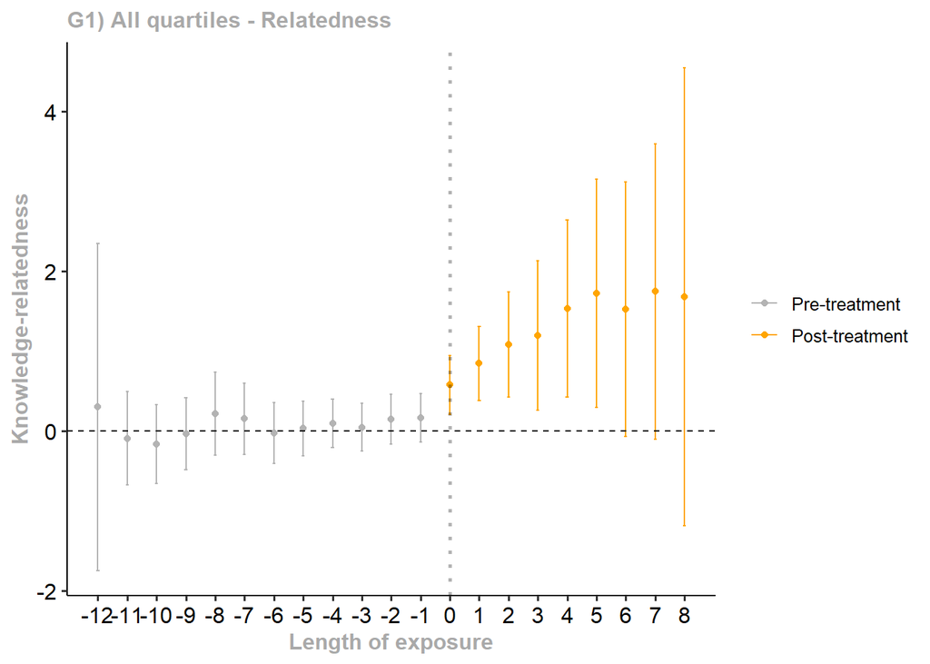

Now we calculate the overall effects on innovative performance. The results are:

```r
summary(agg.simple)
```

```
##
## Call:
## aggte(MP = example_attgt, type = "simple", na.rm = TRUE)
##
## Reference: Callaway, Brantly and Pedro H.C. Sant'Anna.  "Difference-in-Differences with Multiple Time Periods." Journal of Econometrics, Vol. 225, No. 2, pp. 200-230, 2021. <https://doi.org/10.1016/j.jeconom.2020.12.001>, <https://arxiv.org/abs/1803.09015>
##
##
##    ATT    Std. Error     [ 99%  Conf. Int.]
##  18.14        3.3804     9.4326     26.8473 *
##
##
## ---
## Signif. codes: `*' confidence band does not cover 0
##
## Control Group:  Never Treated,  Anticipation Periods:  0
## Estimation Method:  Doubly Robust
```

Let’s see the effects considering dynamic events:

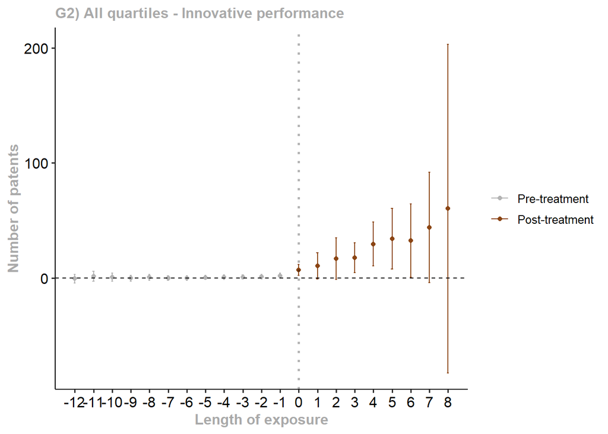

#### Moderating effects (non-standard)

Let’s calculate moderating effects of relatedness on innovative performance. Starting with relatedness without any moderation (i.e., let’s just look at what is the treatment effect of AI using a traditional did approach):

```r
summary(model)
```

```
##
## Call:
## lm(formula = Relatedness_Cos2 ~ treat * post_treatment, data = DataLong_Subs_sim)
##
## Residuals:
##     Min      1Q  Median      3Q     Max
## -15.265 -10.265  -1.265   7.735  43.320
##
## Coefficients:
##                      Estimate Std. Error t value Pr(>|t|)
## (Intercept)           12.0186     0.1147 104.794  < 2e-16 ***
## treat                  0.6618     0.1643   4.028 5.64e-05 ***
## post_treatment         1.2469     0.1925   6.477 9.51e-11 ***
## treat:post_treatment   1.3380     0.2729   4.904 9.45e-07 ***
## ---
## Signif. codes:  0 '***' 0.001 '**' 0.01 '*' 0.05 '.' 0.1 ' ' 1
##
## Residual standard error: 11.13 on 28819 degrees of freedom
##   (6373 observations deleted due to missingness)
## Multiple R-squared:  0.01034,    Adjusted R-squared:  0.01024
## F-statistic: 100.4 on 3 and 28819 DF,  p-value: < 2.2e-16
```

Let’s calculate now the treatment effect of AI using a traditional did approach for innovative performance:

```r
summary(model)
```

```
##
## Call:
## lm(formula = NoPatentsYearGUOtotal ~ treat * post_treatment,
##     data = DataLong_Subs_sim)
##
## Residuals:
##    Min     1Q Median     3Q    Max
## -124.9  -62.3  -53.8  -14.8 3853.1
##
## Coefficients:
##                      Estimate Std. Error t value Pr(>|t|)
## (Intercept)            57.821      1.862  31.048  < 2e-16 ***
## treat                   4.478      2.634   1.700   0.0891 .
## post_treatment         33.084      3.379   9.790  < 2e-16 ***
## treat:post_treatment   29.473      4.779   6.167 7.02e-10 ***
## ---
## Signif. codes:  0 '***' 0.001 '**' 0.01 '*' 0.05 '.' 0.1 ' ' 1
##
## Residual standard error: 206.1 on 35192 degrees of freedom
## Multiple R-squared:  0.01334,    Adjusted R-squared:  0.01326
## F-statistic: 158.6 on 3 and 35192 DF,  p-value: < 2.2e-16
```

Finally, we estimate the moderating effects of relatedness on innovative performance. The effect of innovative performance is shown in the variable “treat:post_treatment”, whereas the moderating effect of relatedness is shown in variable treat:post_treatment:Relatedness_Cos2.

```r
summary(model_moderation)
```

```
##
## Call:
## lm(formula = NoPatentsYearGUOtotal ~ treat * post_treatment *
##     Relatedness_Cos2, data = DataLong_Subs_sim)
##
## Residuals:
##    Min     1Q Median     3Q    Max
## -422.4  -67.7  -13.9   18.2 3655.5
##
## Coefficients:
##                                       Estimate Std. Error t value Pr(>|t|)
## (Intercept)                             1.5153     3.1407   0.482  0.62947
## treat                                 -18.7609     4.5840  -4.093 4.28e-05 ***
## post_treatment                         -2.4439     5.3921  -0.453  0.65038
## Relatedness_Cos2                        6.1295     0.1917  31.973  < 2e-16 ***
## treat:post_treatment                  -21.9771     8.0202  -2.740  0.00614 **
## treat:Relatedness_Cos2                  1.9534     0.2762   7.073 1.55e-12 ***
## post_treatment:Relatedness_Cos2         1.0060     0.3144   3.199  0.00138 **
## treat:post_treatment:Relatedness_Cos2   1.9468     0.4548   4.281 1.87e-05 ***
## ---
## Signif. codes:  0 '***' 0.001 '**' 0.01 '*' 0.05 '.' 0.1 ' ' 1
##
## Residual standard error: 207.2 on 28815 degrees of freedom
##   (6373 observations deleted due to missingness)
## Multiple R-squared:  0.1601, Adjusted R-squared:  0.1599
## F-statistic: 784.9 on 7 and 28815 DF,  p-value: < 2.2e-16
```

### 2.1.2. Standardized - Relatedness and number of patents regardless of sector

Let’s now standardize the values and re estimate the effects for the same variables. Starting with relatedness:

```r
summary(agg.simple)
```

```
##
## Call:
## aggte(MP = example_attgt, type = "simple", na.rm = TRUE)
##
## Reference: Callaway, Brantly and Pedro H.C. Sant'Anna.  "Difference-in-Differences with Multiple Time Periods." Journal of Econometrics, Vol. 225, No. 2, pp. 200-230, 2021. <https://doi.org/10.1016/j.jeconom.2020.12.001>, <https://arxiv.org/abs/1803.09015>
##
##
##     ATT    Std. Error     [ 99%  Conf. Int.]
##  0.0965        0.0188     0.0482      0.1448 *
##
##
## ---
## Signif. codes: `*' confidence band does not cover 0
##
## Control Group:  Never Treated,  Anticipation Periods:  0
## Estimation Method:  Doubly Robust
```

Now, for innovative performance:

```r
summary(agg.simple)
```

```
##
## Call:
## aggte(MP = example_attgt, type = "simple", na.rm = TRUE)
##
## Reference: Callaway, Brantly and Pedro H.C. Sant'Anna.  "Difference-in-Differences with Multiple Time Periods." Journal of Econometrics, Vol. 225, No. 2, pp. 200-230, 2021. <https://doi.org/10.1016/j.jeconom.2020.12.001>, <https://arxiv.org/abs/1803.09015>
##
##
##     ATT    Std. Error     [ 99%  Conf. Int.]
##  0.0874        0.0162     0.0458      0.1291 *
##
##
## ---
## Signif. codes: `*' confidence band does not cover 0
##
## Control Group:  Never Treated,  Anticipation Periods:  0
## Estimation Method:  Doubly Robust
```

#### Moderating effects (standardized)

Let’s start with a traditional did approach to estimate the treatment effects of AI on relatedness:

```r
summary(model)
```

```
##
## Call:
## lm(formula = Relatedness_Cos2 ~ treat * post_treatment, data = DataLong_Subs_sim_standard)
##
## Residuals:
##     Min      1Q  Median      3Q     Max
## -1.3642 -0.9174 -0.1131  0.6912  3.8713
##
## Coefficients:
##                      Estimate Std. Error t value Pr(>|t|)
## (Intercept)          -0.09139    0.01025  -8.917  < 2e-16 ***
## treat                 0.05914    0.01468   4.028 5.64e-05 ***
## post_treatment        0.11143    0.01720   6.477 9.51e-11 ***
## treat:post_treatment  0.11958    0.02438   4.904 9.45e-07 ***
## ---
## Signif. codes:  0 '***' 0.001 '**' 0.01 '*' 0.05 '.' 0.1 ' ' 1
##
## Residual standard error: 0.9949 on 28819 degrees of freedom
##   (6373 observations deleted due to missingness)
## Multiple R-squared:  0.01034,    Adjusted R-squared:  0.01024
## F-statistic: 100.4 on 3 and 28819 DF,  p-value: < 2.2e-16
```

Now innovative performance using a traditional did approach:

```r
summary(model)
```

```
##
## Call:
## lm(formula = NoPatentsYearGUOtotal ~ treat * post_treatment,
##     data = DataLong_Subs_sim_standard)
##
## Residuals:
##     Min      1Q  Median      3Q     Max
## -0.6016 -0.3002 -0.2593 -0.0714 18.5670
##
## Coefficients:
##                       Estimate Std. Error t value Pr(>|t|)
## (Intercept)          -0.080776   0.008974  -9.001  < 2e-16 ***
## treat                 0.021576   0.012691   1.700   0.0891 .
## post_treatment        0.159419   0.016283   9.790  < 2e-16 ***
## treat:post_treatment  0.142023   0.023028   6.167 7.02e-10 ***
## ---
## Signif. codes:  0 '***' 0.001 '**' 0.01 '*' 0.05 '.' 0.1 ' ' 1
##
## Residual standard error: 0.9933 on 35192 degrees of freedom
## Multiple R-squared:  0.01334,    Adjusted R-squared:  0.01326
## F-statistic: 158.6 on 3 and 35192 DF,  p-value: < 2.2e-16
```

Finally, we estimate the moderating effects of relatedness on innovative performance considering standardized values. The effect of innovative performance is shown in the variable “treat:post_treatment”, whereas the moderating effect of relatedness is shown in variable treat:post_treatment:Relatedness_Cos2.

```r
summary(model_moderation)
```

```
##
## Call:
## lm(formula = NoPatentsYearGUOtotal ~ treat * post_treatment *
##     Relatedness_Cos2, data = DataLong_Subs_sim_standard)
##
## Residuals:
##     Min      1Q  Median      3Q     Max
## -2.0354 -0.3265 -0.0670  0.0879 17.6145
##
## Coefficients:
##                                       Estimate Std. Error t value Pr(>|t|)
## (Intercept)                            0.03309    0.01033   3.204  0.00136 **
## treat                                  0.03235    0.01477   2.191  0.02847 *
## post_treatment                         0.05144    0.01729   2.975  0.00293 **
## Relatedness_Cos2                       0.33050    0.01034  31.973  < 2e-16 ***
## treat:post_treatment                   0.01644    0.02465   0.667  0.50476
## treat:Relatedness_Cos2                 0.10533    0.01489   7.073 1.55e-12 ***
## post_treatment:Relatedness_Cos2        0.05425    0.01695   3.199  0.00138 **
## treat:post_treatment:Relatedness_Cos2  0.10497    0.02452   4.281 1.87e-05 ***
## ---
## Signif. codes:  0 '***' 0.001 '**' 0.01 '*' 0.05 '.' 0.1 ' ' 1
##
## Residual standard error: 0.9983 on 28815 degrees of freedom
##   (6373 observations deleted due to missingness)
## Multiple R-squared:  0.1601, Adjusted R-squared:  0.1599
## F-statistic: 784.9 on 7 and 28815 DF,  p-value: < 2.2e-16
```

## 2.2. Measuring effects across sectors

### 2.2.1. Calculate the effects Non-standardized

#### 2.2.1.1. Relatedness

Let’s calculate the effects for relatedness first, considering the closest group (Q1):

```r
summary(agg.simple)
```

```
##
## Call:
## aggte(MP = estim_attgt, type = "simple", na.rm = TRUE)
##
## Reference: Callaway, Brantly and Pedro H.C. Sant'Anna.  "Difference-in-Differences with Multiple Time Periods." Journal of Econometrics, Vol. 225, No. 2, pp. 200-230, 2021. <https://doi.org/10.1016/j.jeconom.2020.12.001>, <https://arxiv.org/abs/1803.09015>
##
##
##     ATT    Std. Error     [ 95%  Conf. Int.]
##  1.7882        0.3785     1.0464        2.53 *
##
##
## ---
## Signif. codes: `*' confidence band does not cover 0
##
## Control Group:  Never Treated,  Anticipation Periods:  0
## Estimation Method:  Doubly Robust
```

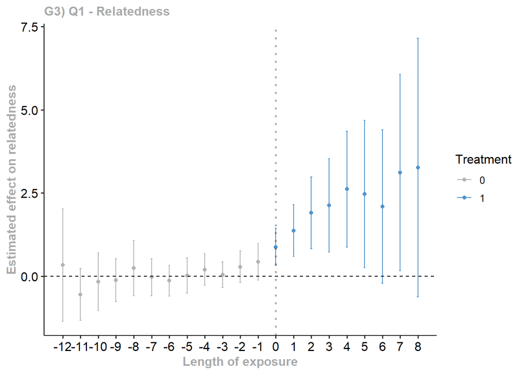

```r
Fig
```

```r
results_df
```

| ATT | Std_Error | CI_90_Low | CI_90_High | CI_95_Low | CI_95_High | CI_99_Low | CI_99_High | Significance | Group | Variable |
| --- | --- | --- | --- | --- | --- | --- | --- | --- | --- | --- |
| 1.788202 | 0.3784794 | 1.165603 | 2.4108 | 1.046382 | 2.530021 | 0.8132389 | 2.763164 | *** | DataLong_Subs_sim_group1 | Relatedness_Cos2 |

IQR

```r
summary(agg.simple)
```

```
##
## Call:
## aggte(MP = estim_attgt, type = "simple", na.rm = TRUE)
##
## Reference: Callaway, Brantly and Pedro H.C. Sant'Anna.  "Difference-in-Differences with Multiple Time Periods." Journal of Econometrics, Vol. 225, No. 2, pp. 200-230, 2021. <https://doi.org/10.1016/j.jeconom.2020.12.001>, <https://arxiv.org/abs/1803.09015>
##
##
##     ATT    Std. Error     [ 95%  Conf. Int.]
##  0.6318        0.2869     0.0695      1.1941 *
##
##
## ---
## Signif. codes: `*' confidence band does not cover 0
##
## Control Group:  Never Treated,  Anticipation Periods:  0
## Estimation Method:  Doubly Robust
```

```r
results_df
```

| ATT | Std_Error | CI_90_Low | CI_90_High | CI_95_Low | CI_95_High | CI_99_Low | CI_99_High | Significance | Group | Variable |
| --- | --- | --- | --- | --- | --- | --- | --- | --- | --- | --- |
| 1.7882017 | 0.3784794 | 1.1656031 | 2.410800 | 1.04638215 | 2.530021 | 0.8132389 | 2.763164 | *** | DataLong_Subs_sim_group1 | Relatedness_Cos2 |
| 0.6317646 | 0.2868993 | 0.1598153 | 1.103714 | 0.06944201 | 1.194087 | -0.1072880 | 1.370817 | ** | DataLong_Subs_sim_group2 | Relatedness_Cos2 |

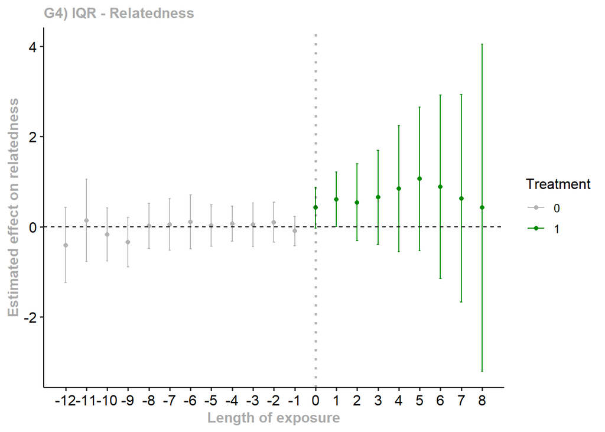

```r
Fig
```

Q4

```r
summary(agg.simple)
```

```
##
## Call:
## aggte(MP = estim_attgt, type = "simple", na.rm = TRUE)
##
## Reference: Callaway, Brantly and Pedro H.C. Sant'Anna.  "Difference-in-Differences with Multiple Time Periods." Journal of Econometrics, Vol. 225, No. 2, pp. 200-230, 2021. <https://doi.org/10.1016/j.jeconom.2020.12.001>, <https://arxiv.org/abs/1803.09015>
##
##
##     ATT    Std. Error     [ 95%  Conf. Int.]
##  0.6172        0.3585    -0.0855      1.3199
##
##
## ---
## Signif. codes: `*' confidence band does not cover 0
##
## Control Group:  Never Treated,  Anticipation Periods:  0
## Estimation Method:  Doubly Robust
```

```r
results_df
```

| ATT | Std_Error | CI_90_Low | CI_90_High | CI_95_Low | CI_95_High | CI_99_Low | CI_99_High | Significance | Group | Variable |
| --- | --- | --- | --- | --- | --- | --- | --- | --- | --- | --- |
| 1.7882017 | 0.3784794 | 1.16560314 | 2.410800 | 1.04638215 | 2.530021 | 0.8132389 | 2.763164 | *** | DataLong_Subs_sim_group1 | Relatedness_Cos2 |
| 0.6317646 | 0.2868993 | 0.15981528 | 1.103714 | 0.06944201 | 1.194087 | -0.1072880 | 1.370817 | ** | DataLong_Subs_sim_group2 | Relatedness_Cos2 |
| 0.6171934 | 0.3585445 | 0.02738762 | 1.206999 | -0.08555391 | 1.319941 | -0.3064174 | 1.540804 | * | DataLong_Subs_sim_group3 | Relatedness_Cos2 |

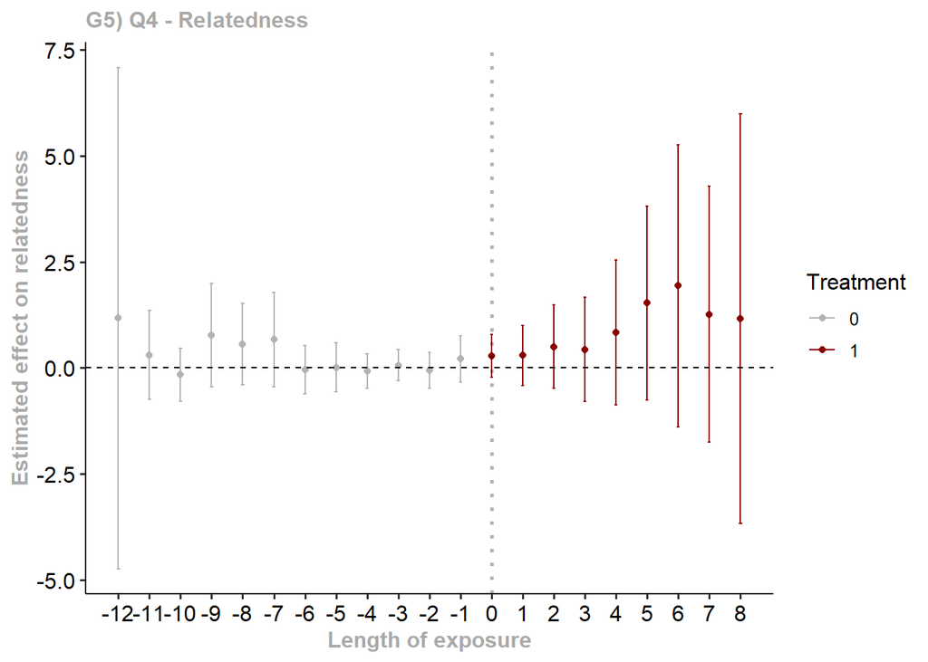

```r
Fig
```

#### 2.2.1.2. Innovative performance

Let’s do the same for innovative performance, starting with the closest group. Q1

```r
summary(agg.simple)
```

```
##
## Call:
## aggte(MP = estim_attgt, type = "simple", na.rm = TRUE)
##
## Reference: Callaway, Brantly and Pedro H.C. Sant'Anna.  "Difference-in-Differences with Multiple Time Periods." Journal of Econometrics, Vol. 225, No. 2, pp. 200-230, 2021. <https://doi.org/10.1016/j.jeconom.2020.12.001>, <https://arxiv.org/abs/1803.09015>
##
##
##      ATT    Std. Error     [ 95%  Conf. Int.]
##  22.2329        6.4305     9.6294     34.8365 *
##
##
## ---
## Signif. codes: `*' confidence band does not cover 0
##
## Control Group:  Never Treated,  Anticipation Periods:  0
## Estimation Method:  Doubly Robust
```

```r
results_df
```

| ATT | Std_Error | CI_90_Low | CI_90_High | CI_95_Low | CI_95_High | CI_99_Low | CI_99_High | Significance | Group | Variable |
| --- | --- | --- | --- | --- | --- | --- | --- | --- | --- | --- |
| 1.7882017 | 0.3784794 | 1.16560314 | 2.410800 | 1.04638215 | 2.530021 | 0.8132389 | 2.763164 | *** | DataLong_Subs_sim_group1 | Relatedness_Cos2 |
| 0.6317646 | 0.2868993 | 0.15981528 | 1.103714 | 0.06944201 | 1.194087 | -0.1072880 | 1.370817 | ** | DataLong_Subs_sim_group2 | Relatedness_Cos2 |
| 0.6171934 | 0.3585445 | 0.02738762 | 1.206999 | -0.08555391 | 1.319941 | -0.3064174 | 1.540804 | * | DataLong_Subs_sim_group3 | Relatedness_Cos2 |
| 22.2329187 | 6.4304992 | 11.65474755 | 32.811090 | 9.62914031 | 34.836697 | 5.6679528 | 38.797885 | *** | DataLong_Subs_sim_group1 | NoPatentsYearGUOtotal |

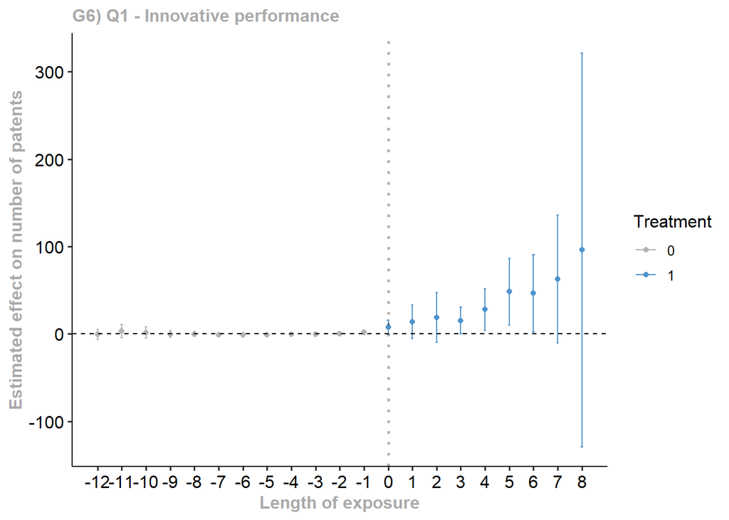

```r
Fig
```

For the interquartile range (IQR):

```r
summary(agg.simple)
```

```
##
## Call:
## aggte(MP = estim_attgt, type = "simple", na.rm = TRUE)
##
## Reference: Callaway, Brantly and Pedro H.C. Sant'Anna.  "Difference-in-Differences with Multiple Time Periods." Journal of Econometrics, Vol. 225, No. 2, pp. 200-230, 2021. <https://doi.org/10.1016/j.jeconom.2020.12.001>, <https://arxiv.org/abs/1803.09015>
##
##
##      ATT    Std. Error     [ 95%  Conf. Int.]
##  11.5939        3.6225     4.4939     18.6939 *
##
##
## ---
## Signif. codes: `*' confidence band does not cover 0
##
## Control Group:  Never Treated,  Anticipation Periods:  0
## Estimation Method:  Doubly Robust
```

```r
results_df
```

| ATT | Std_Error | CI_90_Low | CI_90_High | CI_95_Low | CI_95_High | CI_99_Low | CI_99_High | Significance | Group | Variable |
| --- | --- | --- | --- | --- | --- | --- | --- | --- | --- | --- |
| 1.7882017 | 0.3784794 | 1.16560314 | 2.410800 | 1.04638215 | 2.530021 | 0.8132389 | 2.763164 | *** | DataLong_Subs_sim_group1 | Relatedness_Cos2 |
| 0.6317646 | 0.2868993 | 0.15981528 | 1.103714 | 0.06944201 | 1.194087 | -0.1072880 | 1.370817 | ** | DataLong_Subs_sim_group2 | Relatedness_Cos2 |
| 0.6171934 | 0.3585445 | 0.02738762 | 1.206999 | -0.08555391 | 1.319941 | -0.3064174 | 1.540804 | * | DataLong_Subs_sim_group3 | Relatedness_Cos2 |
| 22.2329187 | 6.4304992 | 11.65474755 | 32.811090 | 9.62914031 | 34.836697 | 5.6679528 | 38.797885 | *** | DataLong_Subs_sim_group1 | NoPatentsYearGUOtotal |
| 11.5939234 | 3.6225247 | 5.63487023 | 17.552976 | 4.49377495 | 18.694072 | 2.2622997 | 20.925547 | *** | DataLong_Subs_sim_group2 | NoPatentsYearGUOtotal |

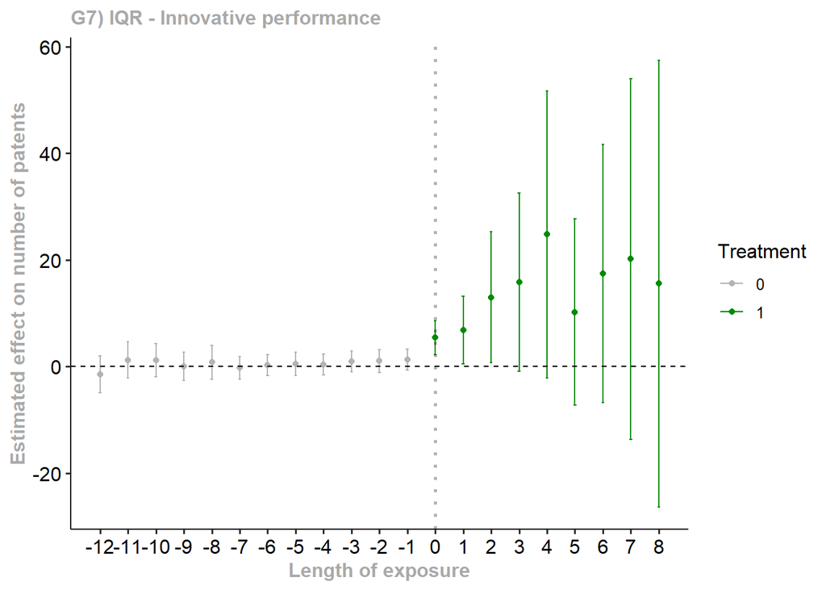

```r
Fig
```

For the lowest quartile (Q4)

```r
summary(agg.simple)
```

```
##
## Call:
## aggte(MP = estim_attgt, type = "simple", na.rm = TRUE)
##
## Reference: Callaway, Brantly and Pedro H.C. Sant'Anna.  "Difference-in-Differences with Multiple Time Periods." Journal of Econometrics, Vol. 225, No. 2, pp. 200-230, 2021. <https://doi.org/10.1016/j.jeconom.2020.12.001>, <https://arxiv.org/abs/1803.09015>
##
##
##      ATT    Std. Error     [ 95%  Conf. Int.]
##  22.2491        6.2997     9.9019     34.5962 *
##
##
## ---
## Signif. codes: `*' confidence band does not cover 0
##
## Control Group:  Never Treated,  Anticipation Periods:  0
## Estimation Method:  Doubly Robust
```

```r
results_df
```

| ATT | Std_Error | CI_90_Low | CI_90_High | CI_95_Low | CI_95_High | CI_99_Low | CI_99_High | Significance | Group | Variable |
| --- | --- | --- | --- | --- | --- | --- | --- | --- | --- | --- |
| 1.7882017 | 0.3784794 | 1.16560314 | 2.410800 | 1.04638215 | 2.530021 | 0.8132389 | 2.763164 | *** | DataLong_Subs_sim_group1 | Relatedness_Cos2 |
| 0.6317646 | 0.2868993 | 0.15981528 | 1.103714 | 0.06944201 | 1.194087 | -0.1072880 | 1.370817 | ** | DataLong_Subs_sim_group2 | Relatedness_Cos2 |
| 0.6171934 | 0.3585445 | 0.02738762 | 1.206999 | -0.08555391 | 1.319941 | -0.3064174 | 1.540804 | * | DataLong_Subs_sim_group3 | Relatedness_Cos2 |
| 22.2329187 | 6.4304992 | 11.65474755 | 32.811090 | 9.62914031 | 34.836697 | 5.6679528 | 38.797885 | *** | DataLong_Subs_sim_group1 | NoPatentsYearGUOtotal |
| 11.5939234 | 3.6225247 | 5.63487023 | 17.552976 | 4.49377495 | 18.694072 | 2.2622997 | 20.925547 | *** | DataLong_Subs_sim_group2 | NoPatentsYearGUOtotal |
| 22.2490594 | 6.2996814 | 11.88608354 | 32.612035 | 9.90168390 | 34.596435 | 6.0210802 | 38.477039 | *** | DataLong_Subs_sim_group3 | NoPatentsYearGUOtotal |

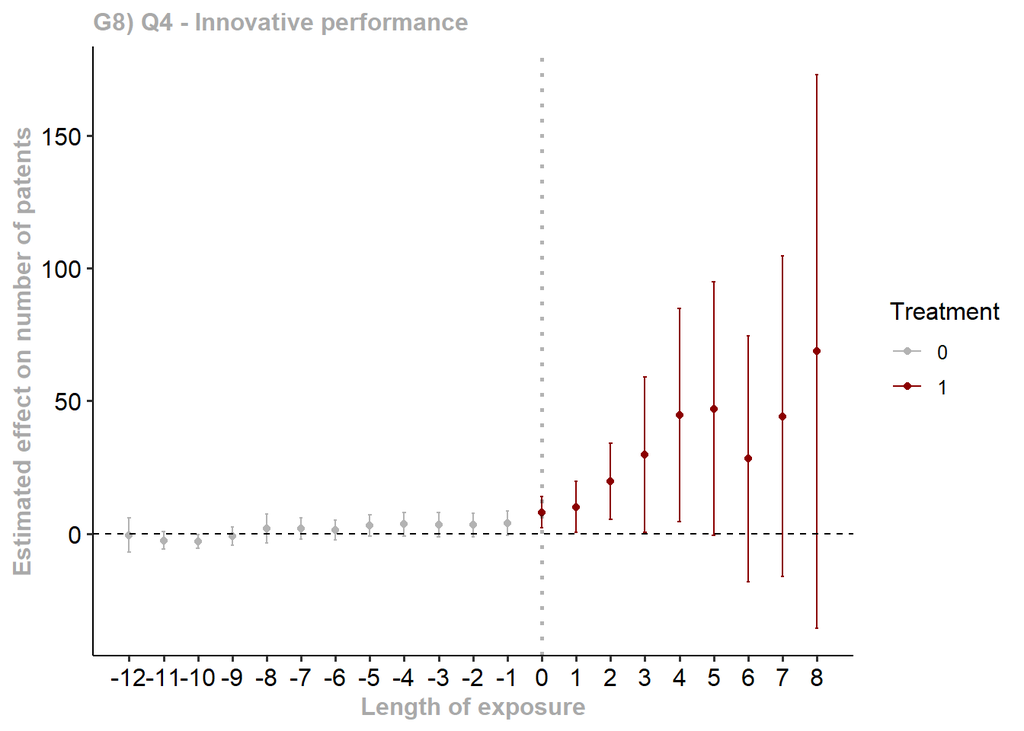

```r
Fig
```

Now we just measure all the effects of the remaining variables linked to dynamic capabilities, and put all of them together in a single table.

```r
results_df
```

| ATT | Std_Error | CI_90_Low | CI_90_High | CI_95_Low | CI_95_High | CI_99_Low | CI_99_High | Significance | Group | Variable |
| --- | --- | --- | --- | --- | --- | --- | --- | --- | --- | --- |
| 1.788201676 | 0.378479351 | 1.165603143 | 2.410800209 | 1.046382148 | 2.5300212050 | 0.8132388673 | 2.763164485 | *** | DataLong_Subs_sim_group1 | Relatedness_Cos2 |
| 0.631764611 | 0.286899288 | 0.159815281 | 1.103713940 | 0.069442005 | 1.1940872158 | -0.1072879562 | 1.370817177 | ** | DataLong_Subs_sim_group2 | Relatedness_Cos2 |
| 0.617193394 | 0.358544544 | 0.027387620 | 1.206999168 | -0.085553911 | 1.3199406997 | -0.3064173500 | 1.540804139 | * | DataLong_Subs_sim_group3 | Relatedness_Cos2 |
| 22.232918706 | 6.430499184 | 11.654747549 | 32.811089864 | 9.629140306 | 34.8366971066 | 5.6679528084 | 38.797884604 | *** | DataLong_Subs_sim_group1 | NoPatentsYearGUOtotal |
| 11.593923362 | 3.622524700 | 5.634870230 | 17.552976494 | 4.493774950 | 18.6940717740 | 2.2622997346 | 20.925546989 | *** | DataLong_Subs_sim_group2 | NoPatentsYearGUOtotal |
| 22.249059443 | 6.299681401 | 11.886083538 | 32.612035348 | 9.901683897 | 34.5964349898 | 6.0210801534 | 38.477038733 | *** | DataLong_Subs_sim_group3 | NoPatentsYearGUOtotal |
| 0.022534366 | 0.008897396 | 0.007898151 | 0.037170582 | 0.005095471 | 0.0399732616 | -0.0003853248 | 0.045454057 | ** | DataLong_Subs_sim_group1 | Specializations_Usage |
| -0.004870707 | 0.007772969 | -0.017657240 | 0.007915826 | -0.020105725 | 0.0103643115 | -0.0248938738 | 0.015152460 |  | DataLong_Subs_sim_group2 | Specializations_Usage |
| -0.002963349 | 0.013179909 | -0.024644300 | 0.018717602 | -0.028795971 | 0.0228692732 | -0.0369147953 | 0.030988097 |  | DataLong_Subs_sim_group3 | Specializations_Usage |
| -0.029307392 | 0.008589918 | -0.043437807 | -0.015176977 | -0.046143631 | -0.0124711531 | -0.0514350205 | -0.007179764 | *** | DataLong_Subs_sim_group1 | HigherUsage |

[output cut: 23 more lines]

These results are saved in the file named **“Results_Effects_non_stand.xlsx”**

### 2.2.2. Calculate the effects Standardized

Let’s do the same for standardized effects, estimating all the effects at once and saving them into a table:

```r
results_df
```

| ATT | Std_Error | CI_90_Low | CI_90_High | CI_95_Low | CI_95_High | CI_99_Low | CI_99_High | Significance | Group | Variable |
| --- | --- | --- | --- | --- | --- | --- | --- | --- | --- | --- |
| 0.16501781 | 0.03192279 | 0.1125048208 | 0.217530809 | 0.102449141 | 0.227586489 | 0.082784701 | 0.24725093 | *** | DataLong_Subs_sim_group1 | Relatedness_Cos2 |
| 0.05524053 | 0.02542016 | 0.0134243569 | 0.097056697 | 0.005417005 | 0.105064049 | -0.010241816 | 0.12072287 | ** | DataLong_Subs_sim_group2 | Relatedness_Cos2 |
| 0.05408179 | 0.03252545 | 0.0005774304 | 0.107586159 | -0.009668086 | 0.117831676 | -0.029703763 | 0.13786735 | * | DataLong_Subs_sim_group3 | Relatedness_Cos2 |
| 0.10085809 | 0.02917478 | 0.0528655735 | 0.148850603 | 0.043675518 | 0.158040659 | 0.025703852 | 0.17601232 | *** | DataLong_Subs_sim_group1 | NoPatentsYearGUOtotal |
| 0.06560706 | 0.02024660 | 0.0323013972 | 0.098912726 | 0.025923717 | 0.105290406 | 0.013451809 | 0.11776231 | *** | DataLong_Subs_sim_group2 | NoPatentsYearGUOtotal |
| 0.09628509 | 0.02741923 | 0.0511804451 | 0.141389727 | 0.042543386 | 0.150026786 | 0.025653138 | 0.16691703 | *** | DataLong_Subs_sim_group3 | NoPatentsYearGUOtotal |
| 0.08482910 | 0.03319868 | 0.0302172727 | 0.139440925 | 0.019759689 | 0.149898509 | -0.000690697 | 0.17034889 | ** | DataLong_Subs_sim_group1 | Specializations_Usage |
| -0.01848629 | 0.02927116 | -0.0666373428 | 0.029664758 | -0.075857757 | 0.038885172 | -0.093888788 | 0.05691620 |  | DataLong_Subs_sim_group2 | Specializations_Usage |
| -0.01298236 | 0.05733522 | -0.1072987958 | 0.081334074 | -0.125359390 | 0.099394668 | -0.160677885 | 0.13471316 |  | DataLong_Subs_sim_group3 | Specializations_Usage |
| -0.10748338 | 0.03109378 | -0.1586326431 | -0.056334115 | -0.168427183 | -0.046539575 | -0.187580950 | -0.02738581 | *** | DataLong_Subs_sim_group1 | HigherUsage |

[output cut: 23 more lines]

These results are saved in a file named **“Results_Effects_stand.xlsx”**

# 3. Descriptive statistics and correlations

Finally, let’s recreate the descriptive statistics shown on the paper.

## 3.1. Statistics All data

Considering the whole dataset, we have:

```r
st(FinalDataset_summary, group = "Size_class",  group.test = TRUE,
                 summ=c('mean(x)','median(x)','sd(x)','min(x)','pctile(x)[25]','pctile(x)[75]','max(x)'), out = 'return')
```

| Variable | Mean | Median | Sd | Min | Pctile[25] | Pctile[75] | Max | Mean | Median | Sd | Min | Pctile[25] | Pctile[75] | Max | Mean | Median | Sd | Min | Pctile[25] | Pctile[75] | Max | Mean | Median | Sd | Min | Pctile[25] | Pctile[75] | Max | Test |
| --- | --- | --- | --- | --- | --- | --- | --- | --- | --- | --- | --- | --- | --- | --- | --- | --- | --- | --- | --- | --- | --- | --- | --- | --- | --- | --- | --- | --- | --- |
| Size_class | Large company |  |  |  |  |  |  | Medium sized company |  |  |  |  |  |  | Small company |  |  |  |  |  |  | Very large company |  |  |  |  |  |  |  |
| Relatedness_Cos2 | 5.5 | 1 | 8.4 | 0 | 0 | 9 | 70 | 3.7 | 0 | 7.1 | 0 | 0 | 4 | 50 | 4.1 | 0 | 7.6 | 0 | 0 | 6 | 54 | 12 | 10 | 12 | 0 | 0 | 20 | 58 | F=1321.82*** |
| NoSubs_calculated | 4.8 | 2 | 11 | 0 | 1 | 5 | 635 | 3.8 | 2 | 12 | 0 | 1 | 4 | 455 | 4.7 | 2 | 13 | 0 | 1 | 4 | 306 | 33 | 10 | 100 | 0 | 4 | 25 | 3481 | F=367.879*** |
| NoSubsWithPatents | 0.49 | 0 | 0.93 | 0 | 0 | 1 | 31 | 0.46 | 0 | 0.82 | 0 | 0 | 1 | 19 | 0.77 | 1 | 1 | 0 | 0 | 1 | 21 | 2.1 | 1 | 4.6 | 0 | 0 | 2 | 112 | F=541.04*** |
| NoPatentsYearGUOtotal | 15 | 4 | 47 | 0 | 2 | 12 | 1777 | 7.9 | 2 | 35 | 0 | 1 | 6 | 1775 | 17 | 2 | 321 | 0 | 1 | 7 | 17615 | 146 | 15 | 662 | 0 | 3 | 72 | 20512 | F=179.223*** |
| No_AI_PatentsYearGUOtotal | 0.055 | 0 | 0.74 | 0 | 0 | 0 | 52 | 0.077 | 0 | 1.4 | 0 | 0 | 0 | 88 | 0.12 | 0 | 1 | 0 | 0 | 0 | 28 | 0.53 | 0 | 8.2 | 0 | 0 | 0 | 566 | F=14.085*** |
| No_employees_Year | 174 | 125 | 171 | 0 | 56 | 230 | 1331 | 30 | 21 | 30 | 0 | 7 | 40 | 169 | 10 | 3 | 273 | 0 | 1 | 4 | 10500 | 6284 | 1131 | 33878 | 0 | 367 | 3803 | 2200000 | F=97.429*** |
| Date_Incorporation | 1986 | 1992 | 26 | 1577 | 1976 | 2003 | 2020 | 1995 | 2000 | 19 | 1798 | 1988 | 2008 | 2020 | 2003 | 2007 | 17 | 1855 | 1999 | 2013 | 2020 | 1982 | 1992 | 32 | 1365 | 1969 | 2003 | 2021 | F=594.202*** |
| Specializations_Usage | 0.74 | 0.87 | 0.32 | 0 | 0.62 | 1 | 1 | 0.71 | 0.87 | 0.36 | 0 | 0.5 | 1 | 1 | 0.72 | 0.89 | 0.36 | 0 | 0.57 | 1 | 1 | 0.79 | 0.88 | 0.26 | 0 | 0.75 | 0.95 | 1 | F=96.862*** |
| HigherUsage | 0.53 | 0.5 | 0.27 | 0.067 | 0.33 | 0.69 | 1 | 0.59 | 0.5 | 0.29 | 0.054 | 0.33 | 1 | 1 | 0.59 | 0.5 | 0.29 | 0.043 | 0.33 | 1 | 1 | 0.42 | 0.34 | 0.25 | 0.045 | 0.23 | 0.5 | 1 | F=702.241*** |

[output cut: 10 more lines]

```r
st(FinalDataset_summary, group = "Quartile",  group.test = TRUE,
               summ=c('mean(x)','median(x)','sd(x)','min(x)','pctile(x)[25]','pctile(x)[75]','max(x)'), out = 'return')
```

| Variable | Mean | Median | Sd | Min | Pctile[25] | Pctile[75] | Max | Mean | Median | Sd | Min | Pctile[25] | Pctile[75] | Max | Mean | Median | Sd | Min | Pctile[25] | Pctile[75] | Max | Mean | Median | Sd | Min | Pctile[25] | Pctile[75] | Max | Test |
| --- | --- | --- | --- | --- | --- | --- | --- | --- | --- | --- | --- | --- | --- | --- | --- | --- | --- | --- | --- | --- | --- | --- | --- | --- | --- | --- | --- | --- | --- |
| Quartile | bottom |  |  |  |  |  |  | Bottom |  |  |  |  |  |  | IQR |  |  |  |  |  |  | Top |  |  |  |  |  |  |  |
| Relatedness_Cos2 | 0.071 | 0 | 0.27 | 0 | 0 | 0 | 1 | 8.4 | 3 | 11 | 0 | 0 | 15 | 56 | 8.1 | 2 | 11 | 0 | 0 | 14 | 70 | 8.2 | 4 | 10 | 0 | 0 | 14 | 56 | F=3.671** |
| NoSubs_calculated | 6.2 | 1.5 | 13 | 0 | 1 | 4 | 48 | 19 | 4 | 75 | 0 | 1 | 12 | 3481 | 16 | 4 | 67 | 0 | 2 | 10 | 3295 | 20 | 5 | 73 | 0 | 2 | 14 | 2657 | F=3.929*** |
| NoSubsWithPatents | 0.36 | 0 | 0.5 | 0 | 0 | 1 | 1 | 1.4 | 0 | 3.9 | 0 | 0 | 1 | 112 | 1.3 | 1 | 3 | 0 | 0 | 1 | 75 | 1.2 | 0 | 3 | 0 | 0 | 1 | 96 | F=8.632*** |
| Size_class | 14 |  |  |  |  |  |  | 9316 |  |  |  |  |  |  | 11961 |  |  |  |  |  |  | 5681 |  |  |  |  |  |  | X2=867.654*** |
| ... Large company | 7 | 50% |  |  |  |  |  | 2671 | 29% |  |  |  |  |  | 3007 | 25% |  |  |  |  |  | 892 | 16% |  |  |  |  |  |  |
| ... Medium sized company | 2 | 14% |  |  |  |  |  | 1389 | 15% |  |  |  |  |  | 2246 | 19% |  |  |  |  |  | 839 | 15% |  |  |  |  |  |  |
| ... Small company | 2 | 14% |  |  |  |  |  | 621 | 7% |  |  |  |  |  | 1799 | 15% |  |  |  |  |  | 693 | 12% |  |  |  |  |  |  |
| ... Very large company | 3 | 21% |  |  |  |  |  | 4635 | 50% |  |  |  |  |  | 4909 | 41% |  |  |  |  |  | 3257 | 57% |  |  |  |  |  |  |
| NoPatentsYearGUOtotal | 1.4 | 1 | 0.84 | 0 | 1 | 1.8 | 3 | 94 | 6 | 548 | 0 | 2 | 28 | 20512 | 58 | 5 | 378 | 0 | 2 | 22 | 17615 | 84 | 5 | 523 | 0 | 1 | 25 | 13581 | F=10.778*** |

[output cut: 10 more lines]

These last two tables are saved as **“Descriptive_statistics_all_MNEs_by_Size_class.csv”** and **“Descriptive_statistics_all_MNEs_by_Quartile.csv”**, respectively.

## 3.2. Statistics matched data

Considering only matched companies, we have:

```r
st(DataLong_Subs_2006_summary,  group = "treat",  group.test = TRUE,
              summ=c('mean(x)','median(x)','sd(x)','min(x)','pctile(x)[25]','pctile(x)[75]','max(x)'), out = 'return')
```

| Variable | Mean | Median | Sd | Min | Pctile[25] | Pctile[75] | Max | Mean | Median | Sd | Min | Pctile[25] | Pctile[75] | Max | Test |
| --- | --- | --- | --- | --- | --- | --- | --- | --- | --- | --- | --- | --- | --- | --- | --- |
| treat | 0 |  |  |  |  |  |  | 1 |  |  |  |  |  |  |  |
| Relatedness_Cos2 | 13 | 11 | 11 | 0 | 2 | 20 | 53 | 14 | 13 | 11 | 0 | 5 | 21 | 53 | F=8.497*** |
| Size_class | 1257 |  |  |  |  |  |  | 1257 |  |  |  |  |  |  | X2=0 |
| ... Large company | 161 | 13% |  |  |  |  |  | 161 | 13% |  |  |  |  |  |  |
| ... Medium sized company | 122 | 10% |  |  |  |  |  | 122 | 10% |  |  |  |  |  |  |
| ... Small company | 98 | 8% |  |  |  |  |  | 98 | 8% |  |  |  |  |  |  |
| ... Very large company | 876 | 70% |  |  |  |  |  | 876 | 70% |  |  |  |  |  |  |
| NoPatentsYearGUOtotal | 88 | 20 | 232 | 0 | 5 | 79 | 3387 | 103 | 28 | 240 | 1 | 6 | 94 | 3137 | F=2.596 |
| No_AI_PatentsYearGUOtotal | 0 | 0 | 0 | 0 | 0 | 0 | 0 | 1.3 | 1 | 0.89 | 1 | 1 | 1 | 9 | F=2832.872*** |
| Date_Incorporation | 1992 | 1999 | 27 | 1654 | 1986 | 2008 | 2019 | 1990 | 1999 | 29 | 1807 | 1987 | 2008 | 2020 | F=1.065 |

[output cut: 18 more lines]

```r
st(DataLong_Subs_2006_summary,  group = "Quartile",  group.test = TRUE,
               summ=c('mean(x)','median(x)','sd(x)','min(x)','pctile(x)[25]','pctile(x)[75]','max(x)'), out = 'return')
```

| Variable | Mean | Median | Sd | Min | Pctile[25] | Pctile[75] | Max | Mean | Median | Sd | Min | Pctile[25] | Pctile[75] | Max | Mean | Median | Sd | Min | Pctile[25] | Pctile[75] | Max | Test |
| --- | --- | --- | --- | --- | --- | --- | --- | --- | --- | --- | --- | --- | --- | --- | --- | --- | --- | --- | --- | --- | --- | --- |
| Quartile | Bottom |  |  |  |  |  |  | IQR |  |  |  |  |  |  | Top |  |  |  |  |  |  |  |
| Relatedness_Cos2 | 15 | 14 | 11 | 0 | 5 | 22 | 47 | 14 | 13 | 11 | 0 | 3 | 21 | 53 | 12 | 11 | 11 | 0 | 1 | 20 | 53 | F=8.758*** |
| Size_class | 432 |  |  |  |  |  |  | 964 |  |  |  |  |  |  | 1118 |  |  |  |  |  |  | X2=52.826*** |
| ... Large company | 54 | 12% |  |  |  |  |  | 156 | 16% |  |  |  |  |  | 112 | 10% |  |  |  |  |  |  |
| ... Medium sized company | 22 | 5% |  |  |  |  |  | 106 | 11% |  |  |  |  |  | 116 | 10% |  |  |  |  |  |  |
| ... Small company | 14 | 3% |  |  |  |  |  | 72 | 7% |  |  |  |  |  | 110 | 10% |  |  |  |  |  |  |
| ... Very large company | 342 | 79% |  |  |  |  |  | 630 | 65% |  |  |  |  |  | 780 | 70% |  |  |  |  |  |  |
| NoPatentsYearGUOtotal | 142 | 49 | 251 | 0 | 11 | 165 | 2167 | 92 | 32 | 198 | 0 | 6 | 96 | 2807 | 80 | 15 | 257 | 0 | 4 | 53 | 3387 | F=10.973*** |
| No_AI_PatentsYearGUOtotal | 0.69 | 0.5 | 0.98 | 0 | 0 | 1 | 9 | 0.62 | 0.5 | 0.81 | 0 | 0 | 1 | 7 | 0.69 | 0.5 | 0.98 | 0 | 0 | 1 | 8 | F=1.748 |
| treat | 0.5 | 0.5 | 0.5 | 0 | 0 | 1 | 1 | 0.5 | 0.5 | 0.5 | 0 | 0 | 1 | 1 | 0.5 | 0.5 | 0.5 | 0 | 0 | 1 | 1 | F=0 |

[output cut: 15 more lines]

```r
st(DataLong_Subs_2006_summary,  group = "Size_class",  group.test = TRUE,
                 summ=c('mean(x)','median(x)','sd(x)','min(x)','pctile(x)[25]','pctile(x)[75]','max(x)'), out = 'return')
```

| Variable | Mean | Median | Sd | Min | Pctile[25] | Pctile[75] | Max | Mean | Median | Sd | Min | Pctile[25] | Pctile[75] | Max | Mean | Median | Sd | Min | Pctile[25] | Pctile[75] | Max | Mean | Median | Sd | Min | Pctile[25] | Pctile[75] | Max | Test |
| --- | --- | --- | --- | --- | --- | --- | --- | --- | --- | --- | --- | --- | --- | --- | --- | --- | --- | --- | --- | --- | --- | --- | --- | --- | --- | --- | --- | --- | --- |
| Size_class | Large company |  |  |  |  |  |  | Medium sized company |  |  |  |  |  |  | Small company |  |  |  |  |  |  | Very large company |  |  |  |  |  |  |  |
| Relatedness_Cos2 | 8.9 | 6 | 8.9 | 0 | 0 | 15 | 36 | 6.5 | 1 | 9 | 0 | 0 | 10 | 42 | 5.3 | 0 | 7.8 | 0 | 0 | 9 | 36 | 16 | 15 | 11 | 0 | 8 | 23 | 53 | F=134.551*** |
| NoPatentsYearGUOtotal | 23 | 10 | 38 | 0 | 4 | 22 | 317 | 11 | 4 | 17 | 0 | 2 | 11 | 116 | 11 | 3 | 27 | 0 | 1 | 9 | 223 | 130 | 44 | 275 | 0 | 12 | 132 | 3387 | F=43.33*** |
| No_AI_PatentsYearGUOtotal | 0.61 | 0.5 | 0.83 | 0 | 0 | 1 | 8 | 0.63 | 0.5 | 0.79 | 0 | 0 | 1 | 5 | 0.64 | 0.5 | 0.81 | 0 | 0 | 1 | 5 | 0.69 | 0.5 | 0.96 | 0 | 0 | 1 | 9 | F=0.752 |
| treat | 0.5 | 0.5 | 0.5 | 0 | 0 | 1 | 1 | 0.5 | 0.5 | 0.5 | 0 | 0 | 1 | 1 | 0.5 | 0.5 | 0.5 | 0 | 0 | 1 | 1 | 0.5 | 0.5 | 0.5 | 0 | 0 | 1 | 1 | F=0 |
| Date_Incorporation | 1994 | 1999 | 25 | 1824 | 1988 | 2009 | 2020 | 2006 | 2009 | 9.6 | 1960 | 2001 | 2013 | 2019 | 2009 | 2011 | 8.9 | 1964 | 2006 | 2014 | 2019 | 1986 | 1996 | 30 | 1654 | 1981 | 2004 | 2019 | F=71.948*** |
| CurrentYear | 2016 | 2017 | 2.3 | 2011 | 2014 | 2018 | 2019 | 2015 | 2016 | 2.2 | 2011 | 2014 | 2017 | 2019 | 2016 | 2016 | 2.1 | 2011 | 2015 | 2018 | 2019 | 2016 | 2016 | 2.5 | 2011 | 2014 | 2018 | 2019 | F=5.091*** |
| NoPatentsYearGUOtotal_avg_fixed | 20 | 8 | 35 | 0.2 | 2.8 | 19 | 318 | 9.3 | 2.4 | 16 | 0 | 0.8 | 9.8 | 101 | 9.3 | 2 | 25 | 0 | 0.8 | 7 | 206 | 119 | 37 | 264 | 0 | 9.8 | 118 | 3282 | F=37.846*** |
| HigherUsage.x | 0.46 | 0.42 | 0.23 | 0.091 | 0.29 | 0.58 | 1 | 0.58 | 0.5 | 0.27 | 0.079 | 0.35 | 0.79 | 1 | 0.59 | 0.5 | 0.28 | 0.14 | 0.36 | 1 | 1 | 0.38 | 0.34 | 0.21 | 0.05 | 0.22 | 0.49 | 1 | F=97.332*** |
| Specializations_Usage.x | 0.79 | 0.87 | 0.25 | 0 | 0.7 | 0.98 | 1 | 0.76 | 0.88 | 0.31 | 0 | 0.67 | 1 | 1 | 0.75 | 0.91 | 0.34 | 0 | 0.67 | 1 | 1 | 0.85 | 0.89 | 0.18 | 0 | 0.82 | 0.94 | 1 | F=22.985*** |

[output cut: 14 more lines]

The last three tables are saved under the names **“Descriptive_statistics_matched_companies_Treated.csv”**, **“Descriptive_statistics_matched_companies_Quartile.csv”**, and **“Descriptive_statistics_matched_companies_Size_class.csv”**, respectively.

## 3.3. Analyse correlations

Finally, let’s recreate the plots of correlations. Starting with the matched sample:

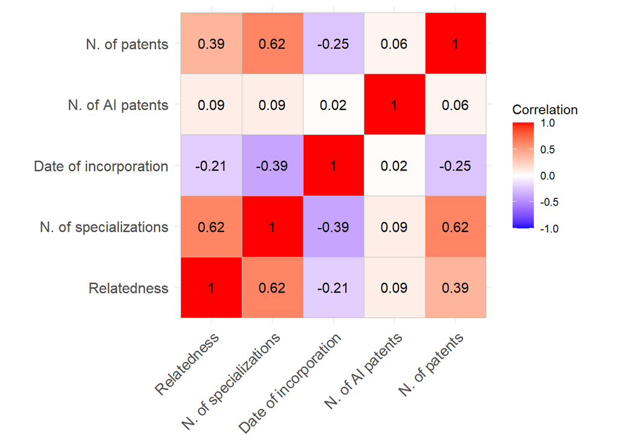

And now for the whole dataset:

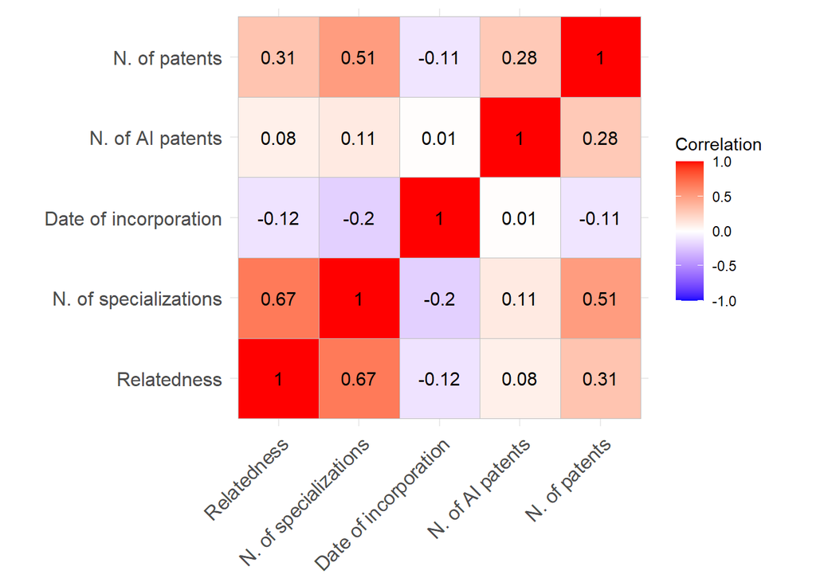